# Reglas de asociación para el dataset Chinook

La idea es generar reglas de asociación para el dataset Chinook, que contiene información de ventas de música. Se busca identificar patrones de compra y relaciones entre productos.

# Carga de librerias y lectura de datos

```r
# install.packages("plyr")
# install.packages("arules")
# install.packages("arulesViz")
# install.packages("tidyverse")


library(plyr)
library(arules)
library(arulesViz)
library(tidyverse)
# library(dplyr)
```

```r
datos <- read.csv("data-1782396576577.csv", sep = ",", dec = ".")


# install.packages("readxl")
# library(readxl)
# datos<- read_excel('Online Retail.xlsx')

head(datos, 10)
```

```
##    id_factura cantidad_vendida precio_unitario_historico ingresos_linea
## 1           1                1                      0.99           0.99
## 2           1                1                      0.99           0.99
## 3           2                1                      0.99           0.99
## 4           2                1                      0.99           0.99
## 5           2                1                      0.99           0.99
## 6           2                1                      0.99           0.99
## 7           3                1                      0.99           0.99
## 8           3                1                      0.99           0.99
## 9           3                1                      0.99           0.99
## 10          3                1                      0.99           0.99
##    llave_fecha id_track_original        nombre_cancion
## 1     20210101                 2     Balls to the Wall
## 2     20210101                 4     Restless and Wild
## 3     20210102                 6 Put The Finger On You
```

[output cut: 29 more lines]

```r
head(datos)
```

```
##   id_factura cantidad_vendida precio_unitario_historico ingresos_linea
## 1          1                1                      0.99           0.99
## 2          1                1                      0.99           0.99
## 3          2                1                      0.99           0.99
## 4          2                1                      0.99           0.99
## 5          2                1                      0.99           0.99
## 6          2                1                      0.99           0.99
##   llave_fecha id_track_original        nombre_cancion
## 1    20210101                 2     Balls to the Wall
## 2    20210101                 4     Restless and Wild
## 3    20210102                 6 Put The Finger On You
## 4    20210102                 8      Inject The Venom
## 5    20210102                10            Evil Walks
## 6    20210102                12    Breaking The Rules
##                                   album artista genero_actual genero_anterior
## 1                     Balls to the Wall  Accept          Rock              NA
## 2                     Restless and Wild  Accept          Rock              NA
## 3 For Those About To Rock We Salute You   AC/DC          Rock              NA
## 4 For Those About To Rock We Salute You   AC/DC          Rock              NA
## 5 For Those About To Rock We Salute You   AC/DC          Rock              NA
## 6 For Those About To Rock We Salute You   AC/DC          Rock              NA
##   registro_activo
## 1            TRUE
## 2            TRUE
## 3            TRUE
## 4            TRUE
## 5            TRUE
## 6            TRUE
```

```r
tail(datos)
```

```
##      id_factura cantidad_vendida precio_unitario_historico ingresos_linea
## 2235        411                1                      0.99           0.99
## 2236        411                1                      0.99           0.99
## 2237        411                1                      0.99           0.99
## 2238        411                1                      0.99           0.99
## 2239        411                1                      0.99           0.99
## 2240        412                1                      1.99           1.99
##      llave_fecha id_track_original
## 2235    20251214              3127
## 2236    20251214              3136
## 2237    20251214              3145
## 2238    20251214              3154
## 2239    20251214              3163
## 2240    20251222              3177
##                                           nombre_cancion               album
## 2235                            Um Homem Chamado Alfredo  Vinicius De Moraes
## 2236                                    Looking For Love       Greatest Hits
## 2237                                     Sweet Lady Luck       Greatest Hits
## 2238 Feirinha da Pavuna/Luz do Repente/Baga�o da Laranja    Ao Vivo [IMPORT]
## 2239                                    Samba pras mo�as    Ao Vivo [IMPORT]
## 2240                                            Hot Girl The Office Season 1
##                 artista genero_actual genero_anterior registro_activo
## 2235 Vin�cius De Moraes         Latin              NA            TRUE
## 2236      Lenny Kravitz         Metal              NA            TRUE
## 2237      Lenny Kravitz         Metal              NA            TRUE
## 2238     Zeca Pagodinho         Latin              NA            TRUE
## 2239     Zeca Pagodinho         Latin              NA            TRUE
## 2240         The Office      TV Shows              NA            TRUE
```

```r
str(datos)
```

```
## 'data.frame':    2240 obs. of  12 variables:
##  $ id_factura               : int  1 1 2 2 2 2 3 3 3 3 ...
##  $ cantidad_vendida         : int  1 1 1 1 1 1 1 1 1 1 ...
##  $ precio_unitario_historico: num  0.99 0.99 0.99 0.99 0.99 0.99 0.99 0.99 0.99 0.99 ...
##  $ ingresos_linea           : num  0.99 0.99 0.99 0.99 0.99 0.99 0.99 0.99 0.99 0.99 ...
##  $ llave_fecha              : int  20210101 20210101 20210102 20210102 20210102 20210102 20210103 20210103 20210103 20210103 ...
##  $ id_track_original        : int  2 4 6 8 10 12 16 20 24 28 ...
##  $ nombre_cancion           : chr  "Balls to the Wall" "Restless and Wild" "Put The Finger On You" "Inject The Venom" ...
##  $ album                    : chr  "Balls to the Wall" "Restless and Wild" "For Those About To Rock We Salute You" "For Those About To Rock We Salute You" ...
##  $ artista                  : chr  "Accept" "Accept" "AC/DC" "AC/DC" ...
##  $ genero_actual            : chr  "Rock" "Rock" "Rock" "Rock" ...
##  $ genero_anterior          : logi  NA NA NA NA NA NA ...
##  $ registro_activo          : logi  TRUE TRUE TRUE TRUE TRUE TRUE ...
```

```r
summary(datos)
```

```
##    id_factura    cantidad_vendida precio_unitario_historico ingresos_linea
##  Min.   :  1.0   Min.   :1        Min.   :0.99              Min.   :0.99
##  1st Qu.:103.0   1st Qu.:1        1st Qu.:0.99              1st Qu.:0.99
##  Median :207.0   Median :1        Median :0.99              Median :0.99
##  Mean   :206.9   Mean   :1        Mean   :1.04              Mean   :1.04
##  3rd Qu.:311.0   3rd Qu.:1        3rd Qu.:0.99              3rd Qu.:0.99
##  Max.   :412.0   Max.   :1        Max.   :1.99              Max.   :1.99
##   llave_fecha       id_track_original nombre_cancion        album
##  Min.   :20210101   Min.   :   1      Length:2240        Length:2240
##  1st Qu.:20220321   1st Qu.: 874      Class :character   Class :character
##  Median :20230624   Median :1708      Mode  :character   Mode  :character
##  Mean   :20230521   Mean   :1718
##  3rd Qu.:20240928   3rd Qu.:2560
##  Max.   :20251222   Max.   :3500
##    artista          genero_actual      genero_anterior registro_activo
##  Length:2240        Length:2240        Mode:logical    Mode:logical
##  Class :character   Class :character   NA's:2240       TRUE:2240
##  Mode  :character   Mode  :character
##
##
##
```

# Transformación inicial de los datos

En esta sección se realiza una limpieza inicial de los datos, eliminando columnas innecesarias y verificando la presencia de valores nulos.

```r
sum(is.na(datos))
```

```
## [1] 2240
```

```r
colSums(is.na(datos))
```

```
##                id_factura          cantidad_vendida precio_unitario_historico
##                         0                         0                         0
##            ingresos_linea               llave_fecha         id_track_original
##                         0                         0                         0
##            nombre_cancion                     album                   artista
##                         0                         0                         0
##             genero_actual           genero_anterior           registro_activo
##                         0                      2240                         0
```

```r
# rowSums(is.na(datos))
datos$count_na_x1tox3 <- rowSums(is.na(datos))

apply(X = is.na(datos), MARGIN = 1, FUN = sum) # Fila
```

[output not shown]

[output cut: 46 more lines]

```r
apply(X = is.na(datos), MARGIN = 2, FUN = sum) # Columna
```

```
##                id_factura          cantidad_vendida precio_unitario_historico
##                         0                         0                         0
##            ingresos_linea               llave_fecha         id_track_original
##                         0                         0                         0
##            nombre_cancion                     album                   artista
##                         0                         0                         0
##             genero_actual           genero_anterior           registro_activo
##                         0                      2240                         0
##           count_na_x1tox3
##                         0
```

```r
datos$genero_anterior <- NULL
datosCompletos <- na.omit(datos)

# se convierte la fecha a tipo Date
datosCompletos$Date <- as.Date(as.character(datosCompletos$llave_fecha), format = "%Y%m%d")
summary(datosCompletos)
```

```
##    id_factura    cantidad_vendida precio_unitario_historico ingresos_linea
##  Min.   :  1.0   Min.   :1        Min.   :0.99              Min.   :0.99
##  1st Qu.:103.0   1st Qu.:1        1st Qu.:0.99              1st Qu.:0.99
##  Median :207.0   Median :1        Median :0.99              Median :0.99
##  Mean   :206.9   Mean   :1        Mean   :1.04              Mean   :1.04
##  3rd Qu.:311.0   3rd Qu.:1        3rd Qu.:0.99              3rd Qu.:0.99
##  Max.   :412.0   Max.   :1        Max.   :1.99              Max.   :1.99
##   llave_fecha       id_track_original nombre_cancion        album
##  Min.   :20210101   Min.   :   1      Length:2240        Length:2240
##  1st Qu.:20220321   1st Qu.: 874      Class :character   Class :character
##  Median :20230624   Median :1708      Mode  :character   Mode  :character
##  Mean   :20230521   Mean   :1718
##  3rd Qu.:20240928   3rd Qu.:2560
##  Max.   :20251222   Max.   :3500
##    artista          genero_actual      registro_activo count_na_x1tox3
##  Length:2240        Length:2240        Mode:logical    Min.   :1
##  Class :character   Class :character   TRUE:2240       1st Qu.:1
##  Mode  :character   Mode  :character                   Median :1
##                                                        Mean   :1
##                                                        3rd Qu.:1
##                                                        Max.   :1
##       Date
##  Min.   :2021-01-01
##  1st Qu.:2022-03-21
##  Median :2023-06-24
##  Mean   :2023-06-25
##  3rd Qu.:2024-09-28
##  Max.   :2025-12-22
```

```r
head(datosCompletos)
```

```
##   id_factura cantidad_vendida precio_unitario_historico ingresos_linea
## 1          1                1                      0.99           0.99
## 2          1                1                      0.99           0.99
## 3          2                1                      0.99           0.99
## 4          2                1                      0.99           0.99
## 5          2                1                      0.99           0.99
## 6          2                1                      0.99           0.99
##   llave_fecha id_track_original        nombre_cancion
## 1    20210101                 2     Balls to the Wall
## 2    20210101                 4     Restless and Wild
## 3    20210102                 6 Put The Finger On You
## 4    20210102                 8      Inject The Venom
## 5    20210102                10            Evil Walks
## 6    20210102                12    Breaking The Rules
##                                   album artista genero_actual registro_activo
## 1                     Balls to the Wall  Accept          Rock            TRUE
## 2                     Restless and Wild  Accept          Rock            TRUE
## 3 For Those About To Rock We Salute You   AC/DC          Rock            TRUE
## 4 For Those About To Rock We Salute You   AC/DC          Rock            TRUE
## 5 For Those About To Rock We Salute You   AC/DC          Rock            TRUE
## 6 For Those About To Rock We Salute You   AC/DC          Rock            TRUE
##   count_na_x1tox3       Date
## 1               1 2021-01-01
## 2               1 2021-01-01
## 3               1 2021-01-02
## 4               1 2021-01-02
## 5               1 2021-01-02
## 6               1 2021-01-02
```

# Convertir los datos originales a formato transacción.

Procederemos a convertir los datos a un formato de transacción, agrupando las compras por factura y fecha, y concatenando los productos comprados en cada transacción.

Luego se guarda el resultado en un archivo CSV para su posterior análisis con reglas de asociación.

```r
# se agrupan las transacciones con igual InvoiceNo y Date
# luego se concatena con una coma

transacciones <- ddply(
  datosCompletos, c("id_factura", "Date"),
  function(dataf) paste(dataf$genero_actual, collapse = ",")
)

# se descartan la fecha y el # de facturas para las reglas de asociación

transacciones$id_factura <- NULL
transacciones$Date <- NULL

# se renombra la columna restante como items

colnames(transacciones) <- c("items")

# se guardan los datos como archivo csv en formato transaccion
write.table(transacciones, "transaccionesOR.csv", quote = FALSE, row.names = FALSE, col.names = FALSE)
```

# Lectura de los datos en formato transacción

Se realiza la lectura del archivo CSV generado anteriormente, especificando el formato de las transacciones y eliminando duplicados.

```r
library(arules)
transacc <- read.transactions("transaccionesOR.csv", sep = ",", format = "basket", quote = "", rm.duplicates = 1)
```

```
## distribution of transactions with duplicates:
## items
##   1   2   3   4   5   6   7   8   9  10  11  12
## 108  11  54  30  33  21  24  13  17  19   8   6
```

```r
# transacc<- read.transactions('transaccionesOR.csv', sep=',', format = 'basket')
```

# Exploración de las transacciones

La exploración de las transacciones permite obtener un resumen de las mismas, así como inspeccionar las primeras transacciones para entender la estructura de los datos.

```r
summary(transacc)
```

```
## transactions as itemMatrix in sparse format with
##  412 rows (elements/itemsets/transactions) and
##  24 columns (items) and a density of 0.07706311
##
## most frequent items:
##               Rock              Latin              Metal Alternative & Punk
##                216                117                 96                 93
##               Jazz            (Other)
##                 41                199
##
## element (itemset/transaction) length distribution:
## sizes
##   1   2   3   4   5   6   7
## 246  76  35  29  17   5   4
##
##    Min. 1st Qu.  Median    Mean 3rd Qu.    Max.
##    1.00    1.00    1.00    1.85    2.00    7.00
##
## includes extended item information - examples:
##               labels
## 1        Alternative
## 2 Alternative & Punk
## 3              Blues
```

```r
inspect(transacc[1:5])
```

```
##     items
## [1] {Rock}
## [2] {Rock}
## [3] {Rock}
## [4] {Jazz,
##      Metal,
##      Rock}
## [5] {Alternative & Punk,
##      Blues,
##      Jazz,
##      Latin,
##      Metal,
##      Rock And Roll}
```

```r
# install.packages("tidyverse")
# como alternativa install.packages("tibble")
# aplicar el paquete tidyverse
df_transacciones <- as(transacc, Class = "data.frame")
# Para que el tamaño de la tabla se ajuste mejor, se convierte el dataframe a tibble
as.tibble(df_transacciones) %>% head(10)
```

```
## # A tibble: 10 × 1
##    items
##    <chr>
##  1 {Rock}
##  2 {Rock}
##  3 {Rock}
##  4 {Jazz,Metal,Rock}
##  5 {Alternative & Punk,Blues,Jazz,Latin,Metal,Rock And Roll}
##  6 {Latin}
##  7 {Latin}
##  8 {Latin}
##  9 {Latin}
## 10 {Latin}
```

# Determinar el tamaño de cada transaccion

El determinar el tamaño de cada transaccion permite identificar la cantidad de items comprados en cada transacción, lo cual es útil para entender el comportamiento de compra de los clientes y para ajustar los parámetros en la generación de reglas de asociación.

```r
tamanyos <- size(transacc)
summary(tamanyos)
```

```
##    Min. 1st Qu.  Median    Mean 3rd Qu.    Max.
##    1.00    1.00    1.00    1.85    2.00    7.00
```

```r
quantile(tamanyos, probs = seq(0, 1, 0.1))
```

```
##   0%  10%  20%  30%  40%  50%  60%  70%  80%  90% 100%
##    1    1    1    1    1    1    2    2    3    4    7
```

# Determinar los items más frecuentes

El determinar los items más frecuentes nos ayuda a identificar los productos que son más populares entre los clientes, lo cual puede ser útil para estrategias de marketing y promociones.

```r
frecuentes <- eclat(transacc, parameter = list(supp = 0.001, maxlen = 10))
```

```
## Eclat
##
## parameter specification:
##  tidLists support minlen maxlen            target  ext
##     FALSE   0.001      1     10 frequent itemsets TRUE
##
## algorithmic control:
##  sparse sort verbose
##       7   -2    TRUE
##
## Absolute minimum support count: 0
##
## create itemset ...
## set transactions ...[24 item(s), 412 transaction(s)] done [0.00s].
## sorting and recoding items ... [24 item(s)] done [0.00s].
## creating sparse bit matrix ... [24 row(s), 412 column(s)] done [0.00s].
## writing  ... [745 set(s)] done [0.00s].
## Creating S4 object  ... done [0.00s].
```

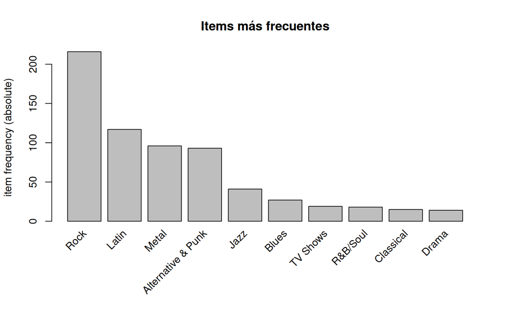

```r
itemFrequencyPlot(transacc, topN = 10, type = "absolute", main = "Items más frecuentes")
```

# Generación de las reglas usando Apriori

Las reglas usando Apriori te permite identificar patrones de compra y relaciones entre productos, lo cual es útil para estrategias de marketing y promociones.

Estas reglas se generan con un soporte mínimo de 0.001 y una confianza mínima de 0.8, limitando la longitud máxima de las reglas a 10.

```r
reglas <- apriori(transacc, parameter = list(supp = 0.001, conf = 0.8, maxlen = 10))
```

```
## Apriori
##
## Parameter specification:
##  confidence minval smax arem  aval originalSupport maxtime support minlen
##         0.8    0.1    1 none FALSE            TRUE       5   0.001      1
##  maxlen target  ext
##      10  rules TRUE
##
## Algorithmic control:
##  filter tree heap memopt load sort verbose
##     0.1 TRUE TRUE  FALSE TRUE    2    TRUE
##
## Absolute minimum support count: 0
##
## set item appearances ...[0 item(s)] done [0.00s].
## set transactions ...[24 item(s), 412 transaction(s)] done [0.00s].
## sorting and recoding items ... [24 item(s)] done [0.00s].
## creating transaction tree ... done [0.00s].
## checking subsets of size 1 2 3 4 5 6 7 done [0.00s].
## writing ... [1374 rule(s)] done [0.00s].
## creating S4 object  ... done [0.00s].
```

```r
inspect(reglas[1:10])
```

```
##      lhs                  rhs                  support     confidence
## [1]  {Science Fiction} => {TV Shows}           0.009708738 1.0
## [2]  {Heavy Metal}     => {Blues}              0.009708738 0.8
## [3]  {Heavy Metal}     => {Metal}              0.012135922 1.0
## [4]  {Heavy Metal}     => {Rock}               0.012135922 1.0
## [5]  {Rock And Roll}   => {Jazz}               0.009708738 1.0
## [6]  {Rock And Roll}   => {Alternative & Punk} 0.009708738 1.0
## [7]  {Rock And Roll}   => {Metal}              0.009708738 1.0
## [8]  {Easy Listening}  => {Soundtrack}         0.009708738 1.0
## [9]  {Easy Listening}  => {Alternative & Punk} 0.009708738 1.0
## [10] {Easy Listening}  => {Latin}              0.009708738 1.0
##      coverage    lift      count
## [1]  0.009708738 21.684211 4
## [2]  0.012135922 12.207407 4
## [3]  0.012135922  4.291667 5
## [4]  0.012135922  1.907407 5
## [5]  0.009708738 10.048780 4
## [6]  0.009708738  4.430108 4
## [7]  0.009708738  4.291667 4
## [8]  0.009708738 34.333333 4
## [9]  0.009708738  4.430108 4
## [10] 0.009708738  3.521368 4
```

Generacion con menos reglas.

```r
# Generar menos reglas
reglas <- apriori(transacc, parameter = list(supp = 0.001, conf = 0.8, maxlen = 4))
```

```
## Apriori
##
## Parameter specification:
##  confidence minval smax arem  aval originalSupport maxtime support minlen
##         0.8    0.1    1 none FALSE            TRUE       5   0.001      1
##  maxlen target  ext
##       4  rules TRUE
##
## Algorithmic control:
##  filter tree heap memopt load sort verbose
##     0.1 TRUE TRUE  FALSE TRUE    2    TRUE
##
## Absolute minimum support count: 0
##
## set item appearances ...[0 item(s)] done [0.00s].
## set transactions ...[24 item(s), 412 transaction(s)] done [0.00s].
## sorting and recoding items ... [24 item(s)] done [0.00s].
## creating transaction tree ... done [0.00s].
## checking subsets of size 1 2 3 4
```

```
##  done [0.00s].
## writing ... [766 rule(s)] done [0.00s].
## creating S4 object  ... done [0.00s].
```

```r
inspect(reglas[1:10])
```

```
##      lhs                  rhs                  support     confidence
## [1]  {Science Fiction} => {TV Shows}           0.009708738 1.0
## [2]  {Heavy Metal}     => {Blues}              0.009708738 0.8
## [3]  {Heavy Metal}     => {Metal}              0.012135922 1.0
## [4]  {Heavy Metal}     => {Rock}               0.012135922 1.0
## [5]  {Rock And Roll}   => {Jazz}               0.009708738 1.0
## [6]  {Rock And Roll}   => {Alternative & Punk} 0.009708738 1.0
## [7]  {Rock And Roll}   => {Metal}              0.009708738 1.0
## [8]  {Easy Listening}  => {Soundtrack}         0.009708738 1.0
## [9]  {Easy Listening}  => {Alternative & Punk} 0.009708738 1.0
## [10] {Easy Listening}  => {Latin}              0.009708738 1.0
##      coverage    lift      count
## [1]  0.009708738 21.684211 4
## [2]  0.012135922 12.207407 4
## [3]  0.012135922  4.291667 5
## [4]  0.012135922  1.907407 5
## [5]  0.009708738 10.048780 4
## [6]  0.009708738  4.430108 4
## [7]  0.009708738  4.291667 4
## [8]  0.009708738 34.333333 4
## [9]  0.009708738  4.430108 4
## [10] 0.009708738  3.521368 4
```

Se procede a eliminar las reglas que son subconjuntos de otras para obtener un conjunto más conciso de reglas significativas.

```r
# eliminar reglas que son subconjuntos de otras
subconjuntos <- which(colSums(is.subset(reglas, reglas)) > 1)

reglasFinal <- reglas[-subconjuntos]
inspect(reglasFinal[1:10])
```

```
##      lhs                  rhs                  support     confidence
## [1]  {Science Fiction} => {TV Shows}           0.009708738 1.0
## [2]  {Heavy Metal}     => {Blues}              0.009708738 0.8
## [3]  {Heavy Metal}     => {Metal}              0.012135922 1.0
## [4]  {Heavy Metal}     => {Rock}               0.012135922 1.0
## [5]  {Rock And Roll}   => {Jazz}               0.009708738 1.0
## [6]  {Rock And Roll}   => {Alternative & Punk} 0.009708738 1.0
## [7]  {Rock And Roll}   => {Metal}              0.009708738 1.0
## [8]  {Easy Listening}  => {Soundtrack}         0.009708738 1.0
## [9]  {Easy Listening}  => {Alternative & Punk} 0.009708738 1.0
## [10] {Easy Listening}  => {Latin}              0.009708738 1.0
##      coverage    lift      count
## [1]  0.009708738 21.684211 4
## [2]  0.012135922 12.207407 4
## [3]  0.012135922  4.291667 5
## [4]  0.012135922  1.907407 5
## [5]  0.009708738 10.048780 4
## [6]  0.009708738  4.430108 4
## [7]  0.009708738  4.291667 4
## [8]  0.009708738 34.333333 4
## [9]  0.009708738  4.430108 4
## [10] 0.009708738  3.521368 4
```

Se procede a ordenar las reglas finales por soporte y se observan las primeras 10 reglas para identificar las más relevantes en términos de frecuencia de ocurrencia.

```r
# se ordena por soporte y se observan las primeras 10 reglas
inspect(sort(reglasFinal, by = "support", decreasing = TRUE)[1:10])
```

```
##      lhs                            rhs     support    confidence coverage
## [1]  {Latin, Metal}              => {Rock}  0.04854369 0.8000000  0.06067961
## [2]  {Alternative & Punk, Latin} => {Rock}  0.03883495 0.8000000  0.04854369
## [3]  {Soundtrack}                => {Rock}  0.02912621 1.0000000  0.02912621
## [4]  {Reggae}                    => {Rock}  0.02669903 0.8461538  0.03155340
## [5]  {World}                     => {Latin} 0.01941748 0.8888889  0.02184466
## [6]  {World}                     => {Rock}  0.01941748 0.8888889  0.02184466
## [7]  {Electronica/Dance}         => {Rock}  0.01456311 0.8571429  0.01699029
## [8]  {Heavy Metal}               => {Metal} 0.01213592 1.0000000  0.01213592
## [9]  {Heavy Metal}               => {Rock}  0.01213592 1.0000000  0.01213592
## [10] {Latin, R&B/Soul}           => {Rock}  0.01213592 0.8333333  0.01456311
##      lift     count
## [1]  1.525926 20
## [2]  1.525926 16
## [3]  1.907407 12
## [4]  1.613960 11
## [5]  3.130104  8
## [6]  1.695473  8
## [7]  1.634921  6
## [8]  4.291667  5
## [9]  1.907407  5
## [10] 1.589506  5
```

Se realiza el filtrado de las reglas finales para obtener aquellas con una confianza superior a 0.85, lo que permite enfocarse en las reglas más confiables y significativas para el análisis.

```r
# se filtran las reglas con confianza superior a 0.15
mejoresReglas <- reglasFinal[quality(reglasFinal)$confidence > 0.85]
inspect(mejoresReglas[1:10])
```

```
##      lhs                  rhs                  support     confidence
## [1]  {Science Fiction} => {TV Shows}           0.009708738 1
## [2]  {Heavy Metal}     => {Metal}              0.012135922 1
## [3]  {Heavy Metal}     => {Rock}               0.012135922 1
## [4]  {Rock And Roll}   => {Jazz}               0.009708738 1
## [5]  {Rock And Roll}   => {Alternative & Punk} 0.009708738 1
## [6]  {Rock And Roll}   => {Metal}              0.009708738 1
## [7]  {Easy Listening}  => {Soundtrack}         0.009708738 1
## [8]  {Easy Listening}  => {Alternative & Punk} 0.009708738 1
## [9]  {Easy Listening}  => {Latin}              0.009708738 1
## [10] {Easy Listening}  => {Rock}               0.009708738 1
##      coverage    lift      count
## [1]  0.009708738 21.684211 4
## [2]  0.012135922  4.291667 5
## [3]  0.012135922  1.907407 5
## [4]  0.009708738 10.048780 4
## [5]  0.009708738  4.430108 4
## [6]  0.009708738  4.291667 4
## [7]  0.009708738 34.333333 4
## [8]  0.009708738  4.430108 4
## [9]  0.009708738  3.521368 4
## [10] 0.009708738  1.907407 4
```